```python
import numpy as np
import matplotlib.pyplot as plt

from scipy import integrate, optimize
```

# First Order Ordinary Differential Equations

$$\boxed{\frac{du}{dt} = f(t,u),\quad u(t_0) = u_0}$$

**[Example] Newton's 1st Order Differential Equation**

$$\frac{du}{dt} = 1 - 3t + u + t^2 + tu,\quad u(0) = 0$$

Approximate solution (Newton, 1671): $$u(t) \simeq t - t^2 + \frac{t^3}{3} - \frac{t^4}{6}$$

Analytic solution: $$u(t) = 3\sqrt{2\pi e}\exp\left(t+\frac{t^2}{2}\right)\left[\mathrm{erf}\left(\frac{\sqrt{2}}{2}(1+t)\right)- \mathrm{erf}\left(\frac{\sqrt{2}}{2}\right) \right] + 4\left[1 - \exp\left(t+\frac{t^2}{2}\right)\right] - t$$

```python
from scipy.special import erf
from numpy import e, pi, exp, sqrt

def f(u, t):
    return 1 - 3*t + u + t**2 + t*u

def u_approx(t):
    return t - t**2 + t**3/3 - t**4/6

def u_anal(t):
    return 3*sqrt(2*pi*e)*exp(t + t**2/2)*(erf((1 + t)/sqrt(2)) \
            - erf(1/np.sqrt(2))) + 4*(1 - exp(t + t**2/2)) - t
```

## IVP Solver `scipy.integrate.odeint`

$$\frac{du}{dt} = f(u, t),\quad (t_0 < t < t_n),\quad u(t_0) = u_0$$

함수 $f(u, t)$에 대한 기본 사용예:

```
def f(u, t): return ...

t = np.linspace(t0, tn, tsize)
sol = integrate.odeint(f, u0, t)
```

함수 $f(u, t, a, b, c)$에 대한 사용예 ($a, b, c$는 매개변수):

```
def f(u, t, a, b, c): return ...

t = np.linspace(t0, tn, tsize)
sol = integrate.odeint(f, u0, t, args=(a, b, c))
```

여기의 직접 코딩한 IVP Solver들은 `odeint`와 동일하게 사용하도록 작성되었다.

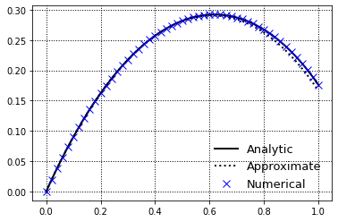

```python
t = np.linspace(0, 1, 51)
sol = integrate.odeint(f, 0, t)

plt.plot(t, u_anal(t),  'k',  lw=2, label="Analytic")
plt.plot(t, u_approx(t), 'k:', lw=2, label="Approximate")
plt.plot(t, sol, 'bx', ms=8, label="Numerical")
plt.legend(fontsize=13, frameon=False)
plt.grid(color='k', ls=':', lw=1)
```

## Single Step Method

$$u_{n+1} = u_n + h\phi(t_n, u_n; h)$$

1. Euler's Method $$u_{n+1} = u_n + hf(t_n, u_n)$$
2. Talyor's Method $$u_{n+1} = u_n + h\left[u'_n + \frac{h}{2!}u''_n + \frac{h^2}{3!}u'''_n + \cdots\right]$$
3. Runge-Kutta Method $$u_{n+1} = u_n + h\sum_{i=1}^{s}b_ik_i,\quad k_i = f\left(t_n+hc_i, u_n+h\sum_{j=1}^{s-1}a_{ij}k_j\right)$$ 여기서 $$\sum_{j=1}^s b_j=1,\quad\sum_{j=1}^{s-1}a_{ij} = c_i$$

### Euler's Method

$$\frac{du}{dt} = f(u, t),\quad (t_0 < t < t_n),\quad u(t_0) = u_0$$

Euler 방법은 Taylor 전개에서 1차항까지 근사하여 해를 구해 나간다. $$u(t+h) \simeq u(t) + u'(t)h \quad\Longrightarrow\quad \boxed{u_{i+1} = u_i + f(u_i,t_i)h}$$

오차를 줄이기 위해서는 $t$의 step size $h$를 작게 한다.

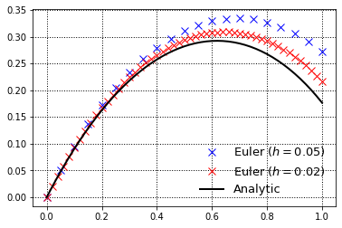

```python
def ivp_euler(f, u0, t, args=()):
    u = np.array([u0]*t.size, dtype=float)
    for i in range(t.size-1):
        h = t[i+1] - t[i]
        u[i+1] = u[i] + h*f(u[i], t[i], *args)
    return u

t1, h1 = np.linspace(0, 1, 21, retstep=True)
sol1 = ivp_euler(f, 0, t1)

t2, h2 = np.linspace(0, 1, 51, retstep=True)
sol2 = ivp_euler(f, 0, t2)

plt.plot(t1, sol1, 'bx', ms=8, label="Euler $(h=%.2f)$" % h1)
plt.plot(t2, sol2, 'rx', ms=8, label="Euler $(h=%.2f)$" % h2)
plt.plot(t2, u_anal(t2), 'k', lw=2, label="Analytic")
plt.legend(fontsize=13, frameon=False)
plt.grid(color='k', ls=':', lw=1)
```

### 2nd Order Runge-Kutta Method

$$\frac{du}{dt} = f(u, t),\quad (t_0 < t < t_n),\quad u(t_0) = u_0$$

근이 다음과 같은 형태로 주어진다고 가정하자. $$\boxed{u(t+h) \simeq u(t) + af(u,t)h + bf\left(u+qf(t,u)h,t+ph\right)h}$$ 여기서, $$f\left(u+qf(t,u)h,t+ph\right) = f(t,u) + p\frac{\partial f}{\partial t}h + q\frac{\partial f}{\partial u}f(u,t)h$$ 대입하면, $$(1)\quad u(t+h) = u(t) + (a+b)f(u,t)h + b\left[p\frac{\partial f}{\partial t} + q\frac{\partial f}{\partial u}f(u,t)\right]h^2$$

그리고, Taylor 전개에서 2차항까지 취하면, $$u(t+h) \simeq u(t) + u'(t)h + \frac{1}{2}u''(t)h^2 = u(t) + f(u,t)h + \frac{1}{2}f'(u,t)h^2$$ 여기서, $$f'(u,t) = \frac{\partial f}{\partial t} + \frac{\partial f}{\partial u}u' = \frac{\partial f}{\partial t} + \frac{\partial f}{\partial u}f(u,t)$$ 대입하면, $$(2)\quad u(t+h) = u(t) + f(u,t)h + \frac{1}{2}\left[\frac{\partial f}{\partial t} + \frac{\partial f}{\partial u}f(u,t)\right]h^2$$

두 식 (1)과 (2)를 비교하면, $$\boxed{a+b=1,\quad b\,p=1/2,\quad b\,q=1/2}$$

계수에 따라 다양한 2차 Runge-Kutta 방법들이 존재한다. 이 중 Ralston 방법과 Heun 방법이 대표적이다.

**Heun's method:** $$a = 1/2,\quad b = 1/2,\quad p = 1,\quad q = 1$$ $$\boxed{ \begin{align*} u_{i+1} &= u_i + \frac{1}{2}(k_1 + k_2)\\ k_1 &= hf(u_i,t_i) \\ k_2 &= hf(u_i + k_1, t_i + h) \end{align*}}$$

**Raslston's method:** $$a = 1/3,\quad b = 2/3,\quad p = 3/4,\quad q = 3/4$$ $$\boxed{\begin{align*} u_{i+1} &= u_i + \frac{1}{3}(k_1 + 2k_2) \\ k_1 &= hf(u_i,t_i) \\ k_2 &= hf(u_i + \tfrac{3}{4}k_1, t_i + \tfrac{3}{4}h) \end{align*}}$$

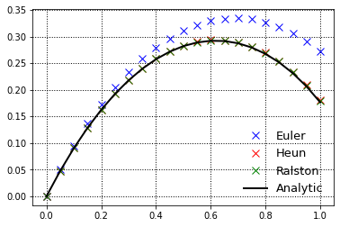

```python
def ivp_heun(f, u0, t, args=()):
    u = np.array([u0]*t.size, dtype=float)
    for i in range(t.size-1):
        h = t[i+1] - t[i]
        k1 = h*f(u[i], t[i], *args)
        k2 = h*f(u[i] + k1, t[i] + h, *args)
        u[i+1] = u[i] + (k1 + k2)/2
    return u

def ivp_ralston(f, u0, t, args=()):
    u = np.array([u0]*t.size, dtype=float)
    for i in range(t.size-1):
        h = t[i+1] - t[i]
        k1 = h*f(u[i], t[i], *args)
        k2 = h*f(u[i] + 3*k1/4, t[i] + 3*h/4, *args)
        u[i+1] = u[i] + (k1 + 2*k2)/3
    return u

t = np.linspace(0, 1, 21)
sol1 = ivp_euler(f, 0, t)
sol2 = ivp_heun(f, 0, t)
sol3 = ivp_ralston(f, 0, t)

plt.plot(t, sol1, 'bx', ms=8, label="Euler")
plt.plot(t, sol2, 'rx', ms=8, label="Heun")
plt.plot(t, sol3, 'gx', ms=8, label="Ralston")
plt.plot(t, u_anal(t), 'k', lw=2, label="Analytic")
plt.legend(fontsize=13, frameon=False)
plt.grid(color='k', ls=':', lw=1)
```

### 4th Order Runge-Kutta Method

$$\frac{du}{dt} = f(u, t),\quad (t_0 < t < t_n),\quad u(t_0) = u_0$$

정확도가 높은 4차 Runge-Kutta 방법을 가장 많이 사용한다. $$\boxed{ \begin{align*} u_{i+1} &= u_i + \frac{1}{6}(k_1 + 2k_2 + 2k_3 + k_4)\\ k_1 &= hf(u_i, t_i) \\ k_2 &= hf(u_i+\tfrac{1}{2}k_1, t_i+\tfrac{1}{2}h)\\ k_3 &= hf(u_i+\tfrac{1}{2}k_2, t_i+\tfrac{1}{2}h)\\ k_4 &= hf(u_i+k_3, t_i+h) \end{align*}}$$

```python
def ivp_rk4(f, u0, t, args=()):
    u = np.array([u0]*t.size, dtype=float)
    for i in range(t.size-1):
        h = t[i+1] - t[i]
        k1 = h*f(u[i], t[i], *args)
        k2 = h*f(u[i] + k1/2, t[i] + h/2, *args)
        k3 = h*f(u[i] + k2/2, t[i] + h/2, *args)
        k4 = h*f(u[i] + k3, t[i] + h, *args)
        u[i+1] = u[i] + (k1 + 2*k2 + 2*k3 + k4)/6
    return u
```

### 5th Order Runge-Kutta Method

$$\frac{du}{dt} = f(u, t),\quad (t_0 < t < t_n),\quad u(t_0) = u_0$$

4차보다 정확한 결과를 얻고 싶을 때는 5차 Runge-Kutta 방법을 사용한다. $$\boxed{ \begin{align*} u_{i+1} &= u_i + \frac{1}{90}(7k_1 + 32k_3 + 12k_4 + 32k_5 + 7k_6)\\ k_1 &= hf(u_i, t_i) \\ k_2 &= hf(u_i+\tfrac{1}{4}k_1, t_i+\tfrac{1}{4}h)\\ k_3 &= hf(u_i+\tfrac{1}{8}k_1+\tfrac{1}{8}k_2, t_i+\tfrac{1}{4}h)\\ k_4 &= hf(u_i-\tfrac{1}{2}k_2+k_3, t_i+\tfrac{1}{2}h) \\ k_5 &= hf(u_i+\tfrac{3}{16}k_1+\tfrac{9}{16}k_4, t_i+\tfrac{3}{4}h) \\ k_6 &= hf(u_i-\tfrac{3}{7}k_1+\tfrac{2}{7}k_2+\tfrac{12}{7}k_3-\tfrac{12}{7}k_4+\tfrac{8}{7}k_5, t_i+h) \end{align*}}$$

```python
def ivp_rk5(f, u0, t, args=()):
    u = np.array([u0]*t.size, dtype=float)
    for i in range(t.size-1):
        h = t[i+1] - t[i]
        k1 = h*f(u[i], t[i], *args)
        k2 = h*f(u[i] + k1/4, t[i] + h/4, *args)
        k3 = h*f(u[i] + k1/8 + k2/8, t[i] + h/4, *args)
        k4 = h*f(u[i] - k2/2 + k3, t[i] + h/2, *args)
        k5 = h*f(u[i] + 3*k1/16 + 9*k4/16, t[i] + 3*h/4, *args)
        k6 = h*f(u[i] - 3*k1/7 + 2*k2/7 + 12*k3/7 - 12*k4/7 + 8*k5/7,
                 t[i] + h, *args)
        u[i+1] = u[i] + (7*k1 + 32*k3 + 12*k4 + 32*k5 + 7*k6)/90
    return u
```

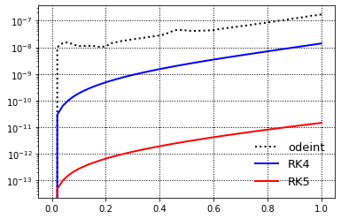

```python
# Errors: odeint vs. Runge-Kutta methods
t = np.linspace(0, 1, 51)
sol0 = integrate.odeint(f, 0, t)[:,0]
sol1 = ivp_rk4(f, 0, t)
sol2 = ivp_rk5(f, 0, t)
exact = u_anal(t)

plt.semilogy(t, abs(exact - sol0), 'k:', lw=2, label="odeint")
plt.semilogy(t, abs(exact - sol1), 'b',  lw=2, label="RK4")
plt.semilogy(t, abs(exact - sol2), 'r',  lw=2, label="RK5")
plt.legend(fontsize=13, frameon=False)
plt.grid(color='k', ls=':', lw=1)
```

### Adaptive Runge-Kutta Method

**Runge-Kutta-Fehlberg Method (RKF45)**

같은 $k_i$ 값들을 이용해서 4차 또는 5차 Runge-Kutta 방법을 계산한다. $$\boxed{ \begin{align*} k_1 &= hf(t_n, u_n) \\ k_2 &= hf(t_n+\tfrac{1}{4}h, u_n+\tfrac{1}{4}k_1)\\ k_3 &= hf(t_n+\tfrac{3}{8}h, u_n+\tfrac{3}{32}k_1+\tfrac{9}{32}k_2)\\ k_4 &= hf(t_n+\tfrac{12}{13}h, u_n+\tfrac{1932}{2197}k_1 - \tfrac{7200}{2197}k_2+\tfrac{7296}{2197}k_3) \\ k_5 &= hf(t_n+h, u_n+\tfrac{439}{216}k_1 - 8k_2 + \tfrac{3680}{513}k_3 -\tfrac{845}{4104}k_4) \\ k_6 &= hf(t_n+\tfrac{1}{2}h, u_n-\tfrac{8}{27}k_1+2k_2 -\tfrac{3544}{2595}k_4+\tfrac{1859}{4104}k_4-\tfrac{11}{40}k_5)\\ u_{n+1} &= u_n + \tfrac{25}{216}k_1 + \tfrac{1408}{2565}k_3 + \tfrac{2197}{4101}k_4 - \tfrac{1}{5}k_5 + O(h^4)\\ u_{n+1}^* &= u_n + \tfrac{16}{135}k_1 + \tfrac{6656}{12825}k_3 + \tfrac{28561}{56430}k_4 = \tfrac{9}{50}k_5 + \tfrac{2}{55}k_6 + O(h^5) \end{align*}}$$

최적 step size $sh$는 기존 $h$ 값에 다음과 같이 구한 상수 $s$ 값을 곱해서 구할 수 있다. 여기서 $\epsilon$은 specified error control tolerance이다. $$s = \left(\frac{\epsilon}{2|u_{n+1}^*-u_{n+1}|}\right)^{1/4} \simeq 0.84\left(\frac{\epsilon}{|u_{n+1}^*-u_{n+1}|}\right)^{1/4}$$

> [참고문헌] Mathews and Fink, Numerical Methods Using Matlab, 4th Ed. (p497)

## Multi-step Method

$$u_{n+1} = u_n + \int_{t_n}^{t_{n+1}}f(t, u)dt$$

**Explicit Method** $$\int_{t_n}^{t_{n+1}}f(t, u)dt = b_1f_n + b_2f_{n-1} + \cdots + b_sf_{n-s+1}$$

이미 계산된 $f$ 값들을 이용하고 단 한번만 $f$ 값을 계산하므로, 앞 선 Runge-Kutta 방법들보다 계산량이 적다. 초기치 값들은 Runge-Kutta 방법을 이용하여 구할 수 있다.

**Implicit Method** $$\int_{t_n}^{t_{n+1}}f(t, u)dt = b_0f_{n+1} + b_1f_n + b_2f_{n-1} + \cdots + b_sf_{n-s+1}$$

$f_{n+1} = f(t_{n+1},u_{n+1})$이므로 양변에 $u_{n+1}$이 포함되어 있다. Newton 방법 같은 nonlinear solver를 이용해 $u_{n+1}$ 값을 구할 수 있다.

### Adams-Bashford Method (Explicit Method)

$$u_{n+1} = u_n + \frac{h}{24}(55f_n - 59f_{n-1} + 37f_{n-2} - 9f_{n-3}) + O(h^4)$$

```python
def ivp_adams_Bashford4(f, u0, t, args=()):
    u = np.array([u0]*t.size, dtype=float)
    u[:4] = ivp_rk4(f, u0, t[:4], args=args)

    fn = np.zeros_like(u)
    fn[:4] = f(u[:4], t[:4], *args)

    for i in range(3, t.size-1):
        h = t[i+1] - t[i]
        u[i+1] = u[i] + (55*fn[i] - 59*fn[i-1] + 37*fn[i-2] - 9*fn[i-3])*h/24
        fn[i+1] = f(u[i+1], t[i+1], *args)
    return u
```

### Adams-Moulton Method (Implicit Method)

$$u_{n+1} = u_n + \frac{h}{24}(9f_{n+1} + 19f_n - 5f_{n-1} + f_{n-2}) + O(h^4)$$

여기서, $f_{n+1}=f(u_{n+1},t_{n+1})$

```python
def ivp_adams_moulton4(f, u0, t, args=()):
    def implicit(u_new):
        fn_new = f(u_new, t[i+1], *args)
        return u_new - u[i] - (9*fn_new + 19*fn[i] - 5*fn[i-1] + fn[i-2])*h/24

    u = np.array([u0]*t.size, dtype=float)
    u[:4] = ivp_rk4(f, u0, t[:4], args=args)

    fn = np.zeros_like(u)
    fn[:4] = f(u[:4], t[:4], *args)

    for i in range(3, t.size-1):
        h = t[i+1] - t[i]
        u[i+1] = optimize.newton(implicit, u[i])
        fn[i+1] = f(u[i+1], t[i+1], *args)
    return u
```

### Predictor-corrector Method

$$\frac{du}{dt} = f(u, t),\quad (t_0 < t < t_n),\quad u(t_0) = u_0$$

Implicit 방법에서 nonlinear solver를 이용하여 $u_{n+1}$ 값을 구하지 않고, Explicit 방법으로 $u_{n+1}$ 값을 대신 사용한다.

**[Predictor] Adams-Bashforth Method** $$u_{n+1}^* = u_n + \frac{h}{24}(55f_n - 59f_{n-1} + 37f_{n-2} - 9f_{n-3})$$

**[Corrector] Adams-Moulton Method** $$u_{n+1} = u_n + \frac{h}{24}(9f_{n+1}^* + 19f_n - 5f_{n-1} + f_{n-2}),\quad f_{n+1}^*=f(u_{n+1}^*,t_{n+1})$$

```python
def ivp_abm4(f, u0, t, args=()):
    u = np.array([u0]*t.size, dtype=float)
    u[:4] = ivp_rk4(f, u0, t[:4], args=args)

    fn = np.zeros_like(u)
    fn[:4] = f(u[:4], t[:4], *args)

    for i in range(3, t.size-1):
        h = t[i+1] - t[i]
        # Adams-Bashford Method
        u_temp = u[i] + (55*fn[i] - 59*fn[i-1] + 37*fn[i-2] - 9*fn[i-3])*h/24
        # Adams-Moulton Method
        fn[i+1] = f(u_temp, t[i+1], *args)
        u[i+1] = u[i] + (9*fn[i+1] + 19*fn[i] - 5*fn[i-1] + fn[i-2])*h/24
    return u
```

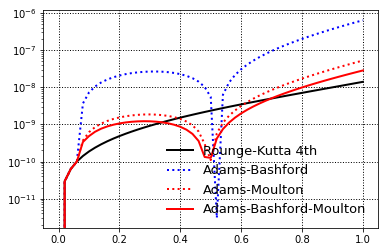

```python
# Errors: Runge-Kutta vs. Adams / Bashford / Moulton methods
t = np.linspace(0, 1, 51)
sol0 = ivp_rk4(f, 0, t)
sol1 = ivp_adams_Bashford4(f, 0, t)
sol2 = ivp_adams_moulton4(f, 0, t)
sol3 = ivp_abm4(f, 0, t)
exact = u_anal(t)

plt.semilogy(t, abs(exact - sol0), 'k', lw=2, label="Rounge-Kutta 4th")
plt.semilogy(t, abs(exact - sol1), 'b:',  lw=2, label="Adams-Bashford")
plt.semilogy(t, abs(exact - sol2), 'r:',  lw=2, label="Adams-Moulton")
plt.semilogy(t, abs(exact - sol3), 'r', lw=2, label="Adams-Bashford-Moulton")
plt.legend(fontsize=13, frameon=False)
plt.grid(color='k', ls=':', lw=1)
```

## General IVP Solver `scipy.integrate.solve_ivp`

$$\boxed{\frac{du}{dt} = f(t,u),\quad u(t_0) = u_0}$$

```
solve_ivp(fun, t_span, y0, method='RK45', t_eval=None, dense_output=False,
        events=None, vectorized=False, args=None, **options)
```

단점 또는 주의할 점:

- `odeint`와 입력 함수 $f$의 변수 순서가 다르다.
- 초기값 `u0` 값을 배열 또는 리스트 (튜플) 형태로 입력한다.
- *`odeint`에 비해 계산 속도가 느리다.*
- *`odeint`에 비해 계산 정확도가 낮다. (오차가 크다)*

장점:

- 구간 $t_0 < t < t_n$의 양 끝값만으로도 해를 구할 수 있다. (Default)
- 구간 $t_0 < t < t_n$에 대한 Interpolation 함수를 반환할 수 있다.
- 구간 $t_0 < t < t_n$ 내에서 특정 Event를 만족하는 조건을 계산할 수 있다.

함수 $f(t, u)$에 대한 기본 사용예 (함수 $f$의 변수 순서에 주의한다. `odeint`와 다르다):

```
def f(t, u): return ...

sol = integrate.solve_ivp(f, [t0, tn], [u0])
```

함수 $f(t, u, a, b, c)$에 대한 사용예 ($a, b, c$는 매개변수):

[output not shown]

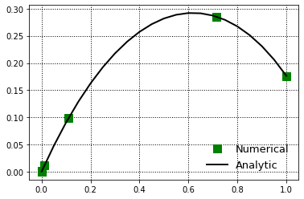

```python
def fun(t, u): return f(u, t)

t = np.linspace(0, 1, 21)
sol = integrate.solve_ivp(fun, [0, 1], [0]) # Default solution

plt.plot(sol.t, sol.y[0], 'gs', ms=10, label="Numerical")
plt.plot(t, u_anal(t), 'k', lw=2, label="Analytic")
plt.legend(fontsize=13, frameon=False)
plt.grid(color='k', ls=':', lw=1)
```

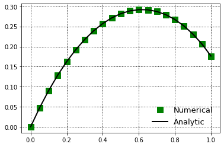

```python
# solve_ivp: solution at t array values
t = np.linspace(0, 1, 21)
sol = integrate.solve_ivp(fun, [0, 1], [0], t_eval=t)

plt.plot(sol.t, sol.y[0], 'gs', ms=10, label="Numerical")
plt.plot(t, u_anal(t), 'k', lw=2, label="Analytic")
plt.legend(fontsize=13, frameon=False)
plt.grid(color='k', ls=':', lw=1)
```

```python
%timeit integrate.solve_ivp(fun, [0, 1], [0], t_eval=t)
```

```
1000 loops, best of 3: 1.1 ms per loop
```

```python
%timeit integrate.odeint(ode_newton, 0, t)
```

```
1000 loops, best of 3: 294 µs per loop
```

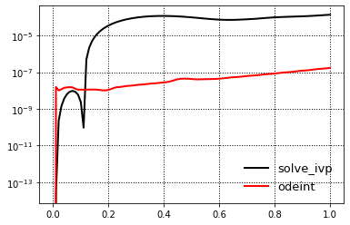

```python
# Errors: solve_ivp vs. odeint
t = np.linspace(0, 1, 101)
sol1 = integrate.solve_ivp(fun, [0, 1], [0], t_eval=t)
sol2 = integrate.odeint(f, 0, t)[:, 0]
exact = u_anal(t)

plt.semilogy(sol1.t, abs(exact - sol1.y[0]), 'k', lw=2, label="solve_ivp")
plt.semilogy(t, abs(exact - sol2), 'r', lw=2, label="odeint")
plt.legend(fontsize=13, frameon=False)
plt.grid(color='k', ls=':', lw=1)
```

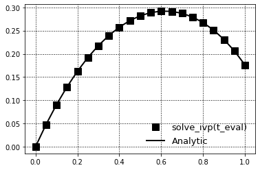

```python
# solve_ivp: solution as a interpolation function
u_inter = integrate.solve_ivp(fun, [0, 1], [0], dense_output=True)

t = np.linspace(0, 1, 21)
plt.plot(t, u_inter.sol(t)[0], 'ks', ms=10, label="solve_ivp(t_eval)")
plt.plot(t, u_anal(t), 'k', lw=2, label="Analytic")
plt.legend(fontsize=13, frameon=False)
plt.grid(color='k', ls=':', lw=1)
```

```
[array([0.11212873]), array([0.26478443, 0.96078715])]
```

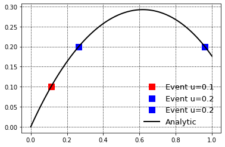

```python
# solve_ivp: time value at events
def u_eq_p1(t, u): return u[0] - 0.1  # u(t) = 0.1 -> t = ?
def u_eq_p2(t, u): return u[0] - 0.2  # u(t) = 0.2 -> t = ?

t = np.linspace(0, 1, 101)
sol = integrate.solve_ivp(fun, [0, 1], [0], events=(u_eq_p1, u_eq_p2))
print(sol.t_events)

t1, u1 = sol.t_events[0], sol.y_events[0][0]
t2, u2 = sol.t_events[1], sol.y_events[1][0]

plt.plot(t1,    u1, 'rs', ms=10, label="Event u=0.1")
plt.plot(t2[0], u2, 'bs', ms=10, label="Event u=0.2")
plt.plot(t2[1], u2, 'bs', ms=10, label="Event u=0.2")
plt.plot(t, u_anal(t), 'k', lw=2, label="Analytic")
plt.legend(fontsize=13, frameon=False)
plt.grid(color='k', ls=':', lw=1)
```

# Systems of 1st Order ODE's

$$\boxed{\left\{\begin{aligned} \frac{dx}{dt} &= f_1(t, x, y), &x(t_0) = x_{0}\\ \frac{dy}{dt} &= f_2(t, x, y), &y(t_0) = y_{0} \end{aligned}\right.}$$

$\mathbf{u} = [x, y]$라고 두면, $\mathbf{u}_0 = [x_0, y_0]$ 이고, $$\mathbf{u}' = [x', y'] = [f_1(t, x, y), f_2(t, x, y)] = \mathbf{F}(t, \mathbf{u})$$

따라서, 하나의 1st Order ODE로 나타낼 수 있다. $$\boxed{\frac{d\mathbf{u}}{dt} = \mathbf{F}(t,\mathbf{u}),\quad \mathbf{u}(t_0) = \mathbf{u}_0}$$

**[Example] Predator-prey models (Lotka-Volterra equations)**

초기조건 $x(0) = 2$, $y(0) = 1$일 때, $0\le t\le 30$에 대해 해를 구하시오. $$\left\{\begin{aligned} \frac{dx}{dt} &= ax - bxy \\ \frac{dy}{dt} &= -cy + dxy \end{aligned}\right.$$ 여기서, $a = 1.2$, $b = 0.6$, $c = 0.8$, $d = 0.3$.

```python
def model(t, u, a, b, c, d):
    x, y = u
    dxdt = a*x - b*x*y
    dydt = -c*y + d*x*y
    return dxdt, dydt
```

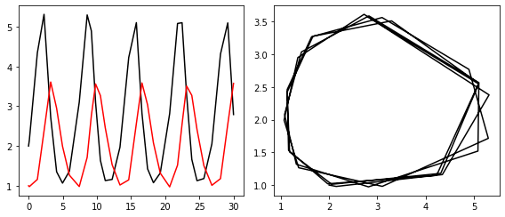

```python
# solve_ivp: method="RK45" (default)
sol = integrate.solve_ivp(model, [0, 30], [2, 1], args=(1.2, 0.6, 0.8, 0.3))

fig, (ax1, ax2) = plt.subplots(1,2, figsize=(8,3.5))
ax1.plot(sol.t, sol.y[0], 'k',  sol.t, sol.y[1], 'r')
ax2.plot(sol.y[0], sol.y[1], 'k')
fig.tight_layout()
```

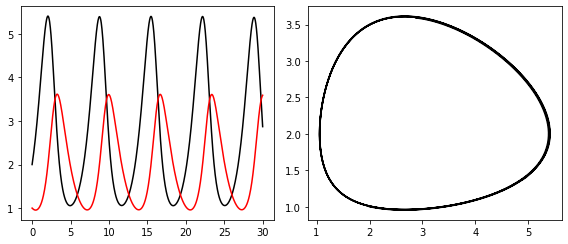

```python
# solve_ivp: method="LSODA" (default)
t = np.linspace(0, 30, 1001)
sol = integrate.solve_ivp(model, [0, 30], [2, 1], args=(1.2, 0.6, 0.8, 0.3),
                          t_eval=t, method="LSODA")

fig, (ax1, ax2) = plt.subplots(1,2, figsize=(8,3.5))
ax1.plot(sol.t, sol.y[0], 'k',  sol.t, sol.y[1], 'r')
ax2.plot(sol.y[0], sol.y[1], 'k')
fig.tight_layout()
```

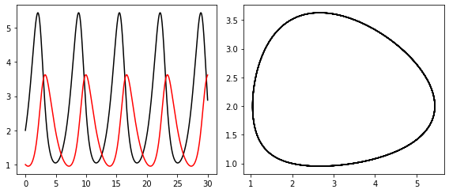

```python
# odeint:
def model_(u, t, a, b, c, d):
    x, y = u
    dxdt = a*x - b*x*y
    dydt = -c*y + d*x*y
    return dxdt, dydt

t = np.linspace(0, 30, 1001)
x, y = integrate.odeint(model_, [2, 1], t, args=(1.2, 0.6, 0.8, 0.3)).T

fig, (ax1, ax2) = plt.subplots(1,2, figsize=(8,3.5))
ax1.plot(t, x, 'k',  t, y, 'r')
ax2.plot(x, y, 'k')
fig.tight_layout()
```

**[Example] Lorentz's Strange attractor**

초기조건 $x(0) = y(0) = z(0) = 5$일 때, $0\le t\le 20$에 대해 해를 구하시오. $$\left\{\begin{aligned} \frac{dx}{dt} &= -a x + a y \\ \frac{dy}{dt} &= r x - y - x z \\ \frac{dz}{dt} &= -b z + xy \end{aligned}\right.$$ 여기서, $a = 10$, $b = 8∕3$, and $r = 28$.

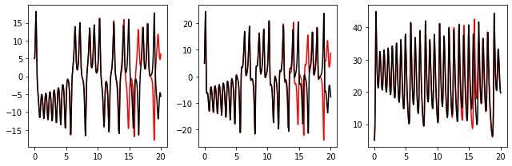

```python
# odeint
def lorentz(u, t, a, b, r):
    x, y, z = u
    dxdt = -a*x + a*y
    dydt = r*x - y - x*z
    dzdt = -b*z + x*y
    return dxdt, dydt, dzdt

t = np.linspace(0, 20, 10001)
sol1 = integrate.odeint(lorentz, [5, 5, 5], t, args=(10, 8/3, 28)).T
sol2 = integrate.odeint(lorentz, [5.001, 5, 5], t, args=(10, 8/3, 28)).T

fig, (ax1, ax2, ax3) = plt.subplots(1,3, figsize=(9,3))
ax1.plot(t, sol1[0], 'r'); ax1.plot(t, sol2[0], 'k')
ax2.plot(t, sol1[1], 'r'); ax2.plot(t, sol2[1], 'k')
ax3.plot(t, sol1[2], 'r'); ax3.plot(t, sol2[2], 'k')
fig.tight_layout()
```

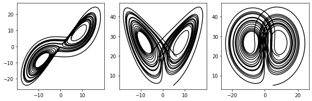

```python
x, y, z = sol1

fig, (ax1, ax2, ax3) = plt.subplots(1,3, figsize=(9,3))
ax1.plot(x, y, 'k')
ax2.plot(x, z, 'k')
ax3.plot(y, z, 'k')
fig.tight_layout()
```

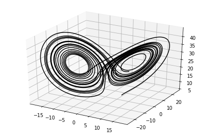

```python
from mpl_toolkits.mplot3d import Axes3D

fig = plt.figure()
ax = fig.add_subplot(111, projection='3d') # Axe3D object
ax.plot(x, y, z, 'k')
fig.tight_layout()
```

# Second Order Ordinary Differential Equations

$$\boxed{\frac{d^2y}{dt^2} = f(t, y, y'),\quad y(t_0) = y_0,\quad y'(t_0) = y'_0}$$

$\mathbf{u} = [y,y']$로 두면, $$\boxed{\frac{d\mathbf{u}}{dt} = [y',f],\quad \mathbf{u}_0 = [y_0,y'_0]}$$

1st Order ODE Solver를 이용해 해를 구할 수 있다.

- `scipy.integrate.solve_ivp`
- `scipy.integrate.odeint` 또는 Runge-Kutta Methods (4차)
- Adams-Molton Method (Multi-step)

또는 2nd Order ODE Solver를 이용할 수도 있다.

- Runge-Kutta-Nystrom Method (4차)

## Rough Method for 2nd Order ODE's

$$u'' = f(u, u', t),\quad u(t_0) = u_0,\quad u'(t_0) = u'_0$$

Taylor 전개에서 2차항까지 취하여 나타내면 다음과 같다. 원리를 이해하기에는 좋으나 계산 정확도가 낮아서 사용하지 않는다. $$\begin{cases} u(t+h) \simeq u(t) + hu'(t) + \dfrac{h^2}{2}u''(t) \\ u'(t+h) \simeq u'(t) + hu''(t) \end{cases} \Rightarrow\quad \begin{cases} u_{i+1} = u_i + hu'_i + \dfrac{h^2}{2}f(t_i,u_i,u'_i) \\ u'_{i+1} = u'_i + hf(t_i,u_i,u'_i) \end{cases}$$

```python
def ivp_rough(f, u0, t, args=()):
    u = np.array([u0]*t.size, dtype=float)
    for i in range(t.size-1):
        h = t[i+1] - t[i]
        fi = f(u[i,0], u[i,1], t[i], *args)
        u[i+1,0] = u[i,0] + u[i,1]*h + fi*h**2/2
        u[i+1,1] = u[i,1] + fi*h
    return u
```

## Runge-Kutta-Nystrom Method

$$u'' = f(u, u', t),\quad u(t_0) = u_0,\quad u'(t_0) = u'_0$$

2차 상미분 방정식을 1차 상미분 방정식으로 변환하지 않고 4차 오차로 해를 구한다.

4차 정확도를 가지는 Runge-Kutta-Nystrom 방법을 이용한 Solver 코드는 다음과 같다. (사용예)

```
def f(u, du, t): return ...

t = np.linspace(t0, tmax, tsize)
sol = ivp_rkn4(f, [u0, du0], t)
```

```python
def ivp_rkn4(f, u0, t, args=()):
    u = np.array([u0]*t.size, dtype=float)
    for i in range(t.size-1):
        h = t[i+1] - t[i]
        k1 = h*f(u[i,0], u[i,1], t[i], *args)/2

        K = (u[i,1]+ k1/2)*h/2
        k2 = h*f(u[i,0] + K, u[i,1] + k1, t[i]+h/2, *args)/2
        k3 = h*f(u[i,0] + K, u[i,1] + k2, t[i]+h/2, *args)/2

        L = (u[i ,1] + k3)*h
        k4 = h*f(u[i,0] + L, u[i,1] + 2*k3, t[i] + h, *args)/2

        u[i+1,0] = u[i,0] + u[i,1]*h + (k1 + k2 + k3)*h/3
        u[i+1,1] = u[i,1] + (k1 + 2*k2 + 2*k3 + k4)/3
    return u
```

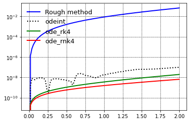

```python
# Errors: odeint vs. 4th Runge-Kutta vs. Runge-Kutta-Nystrom
# y'' = (t + y + y' + 2)/2, y(0) = 0, y'(0) = 0

def func(y, dy, t): return (t + y + dy + 2)/2
def eqns(u, t): y, dy = u; return np.r_[dy, func(y, dy, t)]

t = np.linspace(0, 2, 101)
y1 = integrate.odeint(eqns, [0, 0], t)[:, 0]
y2 = ivp_rk4(eqns, [0, 0], t)[:, 0]
y3 = ivp_rkn4(func, [0, 0], t)[:, 0]
y4 = ivp_rough(func, [0, 0], t)[:, 0]
exact = np.exp(t) - t - 1  # Exact solution

plt.semilogy(t, abs(exact - y4), 'b', lw=2, label="Rough method")
plt.semilogy(t, abs(exact - y1), 'k:', lw=2, label="odeint")
plt.semilogy(t, abs(exact - y2), 'g', lw=2, label="ode_rk4")
plt.semilogy(t, abs(exact - y3), 'r', lw=2, label="ode_rnk4")
plt.legend(fontsize=13, frameon=False, loc="upper left")
plt.grid(color='k', ls=':', lw=1)
```

# Systems of 2nd Order ODE's

$$\boxed{\left\{\begin{aligned} \frac{d^2x}{dt^2} &= f_1(t, x, y, z, x', y', z'), &x(t_0) = x_{0},\quad x'(t_0) = v_{x0}\\ \frac{d^2y}{dt^2} &= f_2(t, x, y, z, x', y', z'), &y(t_0) = y_{0},\quad y'(t_0) = v_{y0}\\ \frac{d^2z}{dt^2} &= f_3(t, x, y, z, x', y', z'), &z(t_0) = z_{0},\quad z'(t_0) = v_{z0}\\ \end{aligned}\right.}$$

1차 미분항을 속도로 및 2차 미분항을 가속도로 나타낼 수 있다. $$\frac{dx}{dt} = v_x, \frac{d^2x}{dt^2} = a_x,\quad \frac{dy}{dt} = v_y, \frac{d^2y}{dt^2} = a_y,\quad \frac{dz}{dt} = v_z, \frac{d^2z}{dt^2} = a_z$$

$\mathbf{u} = [x, y, z, v_x, v_y, v_z]$라고 두면, $$\mathbf{u}' = [v_x, v_y, v_z, a_x, a_y, a_z] = [v_x, v_y, v_z, f_1, f_2, f_3] = \mathbf{F}(t, \mathbf{u})$$

그리고 초기값은 $$\mathbf{u}_0 = [x_0, y_0, z_0, v_{x0}, v_{y0}, v_{z0}] = \mathbf{u}(t_0)$$

따라서, 하나의 1st Order ODE로 나타낼 수 있다. $$\boxed{\mathbf{u}' = \mathbf{F}(t,\mathbf{u}),\quad \mathbf{u}(t_0) = \mathbf{u}_0}$$